# AI & LLM Example

Author

Erik Westlund

Published

June 11, 2025

Modified

June 12, 2025

## Overview

- We’ll use an LLM to help us prepare data for a visualization
- Let’s use the [CDC’s data on influenza vaccination coverage for all ages](https://data.cdc.gov/Flu-Vaccinations/Influenza-Vaccination-Coverage-for-All-Ages-6-Mont/vh55-3he6/about_data)

## Overview

- We’ll use an LLM to help us prepare data for a visualization
- Let’s use the [CDC’s data on influenza vaccination coverage for all ages](https://data.cdc.gov/Flu-Vaccinations/Influenza-Vaccination-Coverage-for-All-Ages-6-Mont/vh55-3he6/about_data)

## Data Preparation

```r
df <- read_csv(here::here("data", "raw", "cdc_Influenza_Vaccination_Coverage_for_All_Ages__6__Months__20250610.csv"))

df |> glimpse()
```

```
Rows: 220,729
Columns: 11
$ Vaccine              <chr> "Seasonal Influenza", "Seasonal Influenza", "Seas…
$ `Geography Type`     <chr> "Counties", "Counties", "Counties", "Counties", "…
$ Geography            <chr> "New Haven", "New Haven", "New Haven", "New Haven…
$ FIPS                 <chr> "09009", "09009", "09009", "09009", "09009", "090…
$ `Season/Survey Year` <chr> "2018", "2021", "2020", "2021", "2018", "2019", "…
$ Month                <dbl> 1, 1, 1, 1, 1, 1, 5, 4, 11, 10, 9, 8, 9, 1, 12, 1…
$ `Dimension Type`     <chr> ">=18 Years", ">=18 Years", "Age", "Age", "Age", …
$ Dimension            <chr> "Non-Medical Setting", "Non-Medical Setting", ">=…
$ `Estimate (%)`       <chr> "45.5", "53.0", "52.4", "50.2", "34.0", "49.5", "…
$ `95% CI (%)`         <chr> "43.9 to 47.2", "46.0 to 60.9", "50.6 to 54.3", "…
$ `Sample Size`        <dbl> NA, NA, NA, NA, NA, NA, 48, 48, 552, 552, 552, 55…
```

## Chat with the LLM

### Data Preparation

From here, we can chat with the LLM to help us prepare the data for a visualization.

Below I provide key aspects of the prompts sent to the ChatGPT LLM as well as the results. I’ve excluded some of the LLM’s missteps.

### Initial Data Exploration

I am working with an unfamiliar data set. Here is a glimpse using dplyr:

```r
df <- read_csv(here::here("data", "raw", "cdc_Influenza_Vaccination_Coverage_for_All_Ages__6__Months__20250610.csv"))
df |> glimpse()
```

```
Rows: 220,729
Columns: 11
$ Vaccine              <chr> "Seasonal Influenza", "Seasonal Influenza", "Seas…
$ `Geography Type`     <chr> "Counties", "Counties", "Counties", "Counties", "…
$ Geography            <chr> "New Haven", "New Haven", "New Haven", "New Haven…
$ FIPS                 <chr> "09009", "09009", "09009", "09009", "09009", "090…
$ `Season/Survey Year` <chr> "2018", "2021", "2020", "2021", "2018", "2019", "…
$ Month                <dbl> 1, 1, 1, 1, 1, 1, 5, 4, 11, 10, 9, 8, 9, 1, 12, 1…
$ `Dimension Type`     <chr> ">=18 Years", ">=18 Years", "Age", "Age", "Age", …
$ Dimension            <chr> "Non-Medical Setting", "Non-Medical Setting", ">=…
$ `Estimate (%)`       <chr> "45.5", "53.0", "52.4", "50.2", "34.0", "49.5", "…
$ `95% CI (%)`         <chr> "43.9 to 47.2", "46.0 to 60.9", "50.6 to 54.3", "…
$ `Sample Size`        <dbl> NA, NA, NA, NA, NA, NA, 48, 48, 552, 552, 552, 55…
```

The bot then summarized the data set.

Using the following prompt, we then sent the LLM the actual data file for more context (🚨 do not do this with private data! 🚨):

“I am actually going to give you the file. Interpret it. We are going to use dplyr and ggplot2 to prepare it and visualize aspects of it. Tell me what you see.”

It responded with a summary, warning us about some of the odd structures of the data.

We then asked it to clean the data:

“Yes, let’s get clean, standardized column names. Let’s make all factor variables factor types. Let’s extract the confidence intervals into separate columns. Let’s just start there. Give me R code that I can paste into RStudio.”

Please note from here on out, ChatGPT gave us code that includes library calls and new code. The library calls are loaded above.

It first gave us back broken code because it did not understand fully the results of applying `clean_names()` to the data.

We eventually sent it the following, explaining the data structure, after which it recovered:

```r
# Clean and prepare
clean_df <- df |>
  clean_names() |>
  mutate(
    vaccine = factor(vaccine),
    geography_type = factor(geography_type),
    geography = factor(geography),
    season_survey_year = factor(season_survey_year),
    dimension_type = factor(dimension_type),
    dimension = factor(dimension),
    estimate = as.numeric(str_replace(estimate_percent, "[^0-9.]", "")),
    ci_clean = str_remove(x95_percent_ci_percent, " ‡| †"),
    ci_lower = as.numeric(str_extract(ci_clean, "^[0-9.]+")),
    ci_upper = as.numeric(str_extract(ci_clean, "[0-9.]+$"))
  )
# Preview result
glimpse(clean_df)
```

```
Rows: 220,729
Columns: 15
$ vaccine                <fct> "Seasonal Influenza", "Seasonal Influenza", "Se…
$ geography_type         <fct> Counties, Counties, Counties, Counties, Countie…
$ geography              <fct> New Haven, New Haven, New Haven, New Haven, New…
$ fips                   <chr> "09009", "09009", "09009", "09009", "09009", "0…
$ season_survey_year     <fct> 2018, 2021, 2020, 2021, 2018, 2019, 2009-10, 20…
$ month                  <dbl> 1, 1, 1, 1, 1, 1, 5, 4, 11, 10, 9, 8, 9, 1, 12,…
$ dimension_type         <fct> >=18 Years, >=18 Years, Age, Age, Age, Age, Rac…
$ dimension              <fct> "Non-Medical Setting", "Non-Medical Setting", "…
$ estimate_percent       <chr> "45.5", "53.0", "52.4", "50.2", "34.0", "49.5",…
$ x95_percent_ci_percent <chr> "43.9 to 47.2", "46.0 to 60.9", "50.6 to 54.3",…
$ sample_size            <dbl> NA, NA, NA, NA, NA, NA, 48, 48, 552, 552, 552, …
$ estimate               <dbl> 45.5, 53.0, 52.4, 50.2, 34.0, 49.5, 57.7, 57.7,…
$ ci_clean               <chr> "43.9 to 47.2", "46.0 to 60.9", "50.6 to 54.3",…
$ ci_lower               <dbl> 43.9, 46.0, 50.6, 45.4, 32.6, 47.8, 40.2, 40.2,…
$ ci_upper               <dbl> 47.2, 60.9, 54.3, 55.8, 35.5, 51.3, 75.2, 75.2,…
```

### Data Summary

We then sent it this to inform it of the structure of the data, which is somewhat unusual:

```r
table(clean_df$dimension)
```

```
                                             >=18 Years
                                                  26534
                                             >=6 Months
                                                  10449
                                             >=65 Years
                                                  10903
                                            13-17 Years
                                                  10265
                                            18-49 Years
                                                   9931
                               18-49 Years at High Risk
                                                  11038
                           18-49 Years not at High Risk
                                                   9257
                                            18-64 Years
                                                   9942
                               18-64 Years at High Risk
                                                   9898
                           18-64 Years not at High Risk
                                                   8018
                               25-64 Years at High Risk
                                                    496
                25-64 Years not in Initial Target Group
                                                    496
                                             5-12 Years
                                                  10279
                                            50-64 Years
                                                  11125
                                    6 Months - 17 Years
                                                  12018
                                     6 Months - 4 Years
                                                  10282
6 Months - 64 Years at High Risk (Initial Target Group)
                                                    496
         American Indian or Alaska Native, Non-Hispanic
                                                   1702
                                    Asian, Non-Hispanic
                                                   1712
                                    Black, Non-Hispanic
                                                  11067
                                             Greater 65
                                                    770
                              Greater than 18 Years flu
                                                    770
                              Greater than 6 Months flu
                                                    682
                                               Hispanic
                                                  11106
                                        Medical Setting
                                                    770
                                    Non-Medical Setting
                                                   6975
                  Other or Multiple Races, Non-Hispanic
                                                  11093
                                         Pharmacy/Store
                                                    770
                                                 School
                                                    198
                                    White, Non-Hispanic
                                                  11115
                                              Workplace
                                                    572
```

```r
table(clean_df$dimension_type)
```

```
         >=18 Years          >=65 Years         18-49 Years         18-64 Years
               6829                 416                 416                 416
        50-64 Years 6 Months - 17 Years                 Age  Race and Ethnicity
                416                 792              163649               47795
```

Here is what we have:

Please notice that the age categories have overlap, so it’s clear that these data are pre-aggregated, and we’ll want to make sure we use mutually exclusive categories.

Here is what we want:

We want to create a time series that shows the vaccination rate, by age, over time.

Before you give me code, what do you recommend?

It went over challenges and recommendations.

We then asked it:

“OK, give me that dataframe before we visualize”

```r
mutually_exclusive_ages <- c(
  "6 Months - 4 Years",
  "5-12 Years",
  "13-17 Years",
  "18-49 Years",
  "50-64 Years",
  ">=65 Years"
)

# Build the cleaned time series dataframe
age_time_series <- clean_df |>
  filter(
    dimension_type == "Age",
    dimension %in% mutually_exclusive_ages,
    !is.na(estimate)
  ) |>
  group_by(season_survey_year, age_group = dimension) |>
  summarise(
    mean_estimate = mean(estimate, na.rm = TRUE),
    n_records = n(),
    .groups = "drop"
  ) |>
  mutate(
    age_group = fct_relevel(age_group, mutually_exclusive_ages)
  )

# View the resulting structure
glimpse(age_time_series)
```

```
Rows: 85
Columns: 4
$ season_survey_year <fct> 2009-10, 2009-10, 2010-11, 2010-11, 2010-11, 2010-1…
$ age_group          <fct> ">=65 Years", "50-64 Years", ">=65 Years", "13-17 Y…
$ mean_estimate      <dbl> 46.28232, 38.60872, 52.04114, 30.16828, 25.02017, 4…
$ n_records          <int> 1680, 1158, 598, 558, 575, 585, 580, 582, 602, 562,…
```

### Data Visualization

With the data now prepared and us asking for a line plot broken apart by age group, it gave us the following code, which worked the first time:

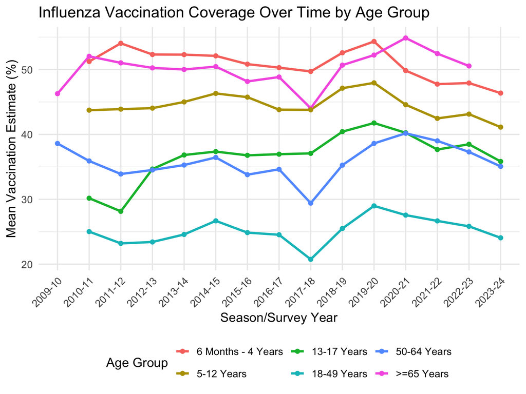

```r
ggplot(age_time_series, aes(x = season_survey_year, y = mean_estimate, group = age_group, color = age_group)) +
  geom_line(linewidth = 1.2) +
  geom_point(size = 2) +
  labs(
    title = "Influenza Vaccination Coverage Over Time by Age Group",
    x = "Season/Survey Year",
    y = "Mean Vaccination Estimate (%)",
    color = "Age Group"
  ) +
  theme_minimal(base_size = 14) +
  theme(
    axis.text.x = element_text(angle = 45, hjust = 1),
    legend.position = "bottom"
  )
```

This image needs refinement, which ChatGPT would happily provide if we continued, but it worked. We wrote zero code ourselves.